# Kenya WIRI Index

GTI & WIN

9/1/2021

# Workflow

[interactive chart not shown]

# Loading Data

This requires three data sets: a) procurement data, b) pipe cost-length data, c) water contract classification (CPV)

```r
# A) Read Procurement Data
df <- read_csv("Inputs/kenya_update.csv")

# B.1) Read Pipe Data

# #Pipe length
# pipelength <- read.csv("Inputs/KE_pipelength.csv") %>%
#   select(year, pipelength, country)

# B.2) Read PPP Conversion Factor Data

bf_wb_ppp <- WDI(country="KE", indicator=c("PA.NUS.PRVT.PP")) %>%
  rename(bf_wb_ppp=PA.NUS.PRVT.PP) %>%
  select(year, bf_wb_ppp, country)

# B.3) Read Survey Data on Experiences
survey_data <- readRDS("Inputs/Afrob_aggregates.rds")
survey_data <- survey_data %>% select(settlement_name, year, n, bribes)

# # B.4) Read Survey Data on Perceptions
# win_survey <- read.csv("Inputs/win_survey.csv") %>% select(settlement_name, year, win_score)
```

```r
# C) Read Water Contract Classification Data

water_cpvs <- read.csv("Inputs/water_cpvs.csv")
# #If Predetermined settlments uncomment
# water_settlements<-c("Nairobi","Busia","Nyeri","Kitui","Uasin Gishu","Makueni", "Mombasa", "Meru")
investment<-c(16,31,32,34,35,42,43,48,44,45,71)
operation<-c(03,09,15,18,19,22,24,30,33,37,38,39,41,70,50,51,60,63,64,65,66,72,73,75,77,79,80,85,90,92,98,55)
other<-c(14,76)
pipes<-c(45232150,44162500,45232411,45232440,45232100,45232121,45232130,45231300,44134000,44163130,44160000,44161000,45231100,45231110,45231112)
```

# Identifying Water Contracts

We assign each public procurement contract to one of the three pillars (investment, operations and client utility interaction) using product codes specific to the nature of W&S activity defined by public procurement data systems such as the Common Procurement Vocabulary (CPV) codes and the United Nations Standard Products and Services Code (UNSPSC). The data is collected using countries’ national public procurement portals.

Public Procurement Risk Indicator Definitions

| Indicator | Definition |
| --- | --- |
| Length of decision period | 100=LENGTH OF DECISION PERIOD IS UNRELATED TO CORRUPTION RISKS, 0=LENGTH OF DECISION PERIOD OR MISSING DECISION PERIOD IS RELATED TO CORRUPTION RISKS |
| Call for tenders publication | 100=CALL FOR TENDER PUBLISHED IN OFFICIAL JOURNAL, 0=OTHERWISE |
| Length of advertisement period | 100=LENGTH OF ADVERTISEMENT PERIOD IS UNRELATED TO CORRUPTION RISKS, 0=LENGTH OF ADVERTISEMENT PERIOD OR MISSING DECISION PERIOD IS RELATED TO CORRUPTION RISKS |
| Procedure type | 100=OPEN, 0=NON-OPEN |
| Single bidder contract | 100=MORE THAN 1 BID RECEIVED, 0=1 BID RECEIVED |

```r
#Water Contracts ID
df <- df %>%
  filter(!is.na(tender_year)) %>%
  mutate(
    #General cleaning
    tender_title=tolower(tender_title),
    tender_title=stringi::stri_trans_general(tender_title, "Latin-ASCII"),
    buyer_name=tolower(buyer_name),
    buyer_name=stringi::stri_trans_general(buyer_name, "Latin-ASCII"),
    bidder_name=tolower(bidder_name),
    bidder_name=stringi::stri_trans_general(bidder_name, "Latin-ASCII"),
    tender_cpvs_8=substr(tender_cpvs,1,8),
    tender_cpvs_6=substr(tender_cpvs,1,6),
    tender_cpvs_4=substr(tender_cpvs,1,4),
    tender_cpvs_2=substr(tender_cpvs,1,2),
    #CPV Codes Matching
    water_cpv=ifelse(tender_cpvs%in%unique(water_cpvs$cpv_full),1,0),
    water_cpv_8=ifelse(tender_cpvs_8%in%unique(water_cpvs$cpv_short_8),1,0),
    water_cpv_6=ifelse(tender_cpvs_6%in%unique(water_cpvs$cpv_short_6),1,0),
    water_cpv_4=ifelse(tender_cpvs_4%in%unique(water_cpvs$cpv_short_4),1,0),
    water_cpv_2=ifelse(tender_cpvs_2%in%unique(water_cpvs$cpv_short_2),1,0),
    #Buyer Name Matching
    water_buyername=case_when(
      #broad
      grepl("water",buyer_name)~1,
      grepl("sewe+",buyer_name)~1,
      grepl("pip+",buyer_name)~1,
      #narrow
      (grepl("housing",buyer_name)&grepl("development",buyer_name))~1,
      grepl("wasre|irrigation|sewer",buyer_name)~1,
      (grepl("ministry|sanitation|project|authority",buyer_name)
       &grepl("water",buyer_name))~1,
      (grepl("kenya|institute|towers|national|pipe",buyer_name)
       &grepl("water",buyer_name))~1,
      # (grepl("nairobi|busia|nyeri|kitui|uasin|makueni|mombasa|meru",buyer_name)
      #  &grepl("metropolis|sanitation",buyer_name))~1,
      (grepl("athi",buyer_name)
       &grepl("water",buyer_name)
       &grepl("works",buyer_name))~1,
      # (grepl("nairobi|busia|nyeri|kitui|uasin|makueni|mombasa|meru",buyer_name)
      #  &grepl("sewe+",buyer_name))~1,
      (grepl("pipe+",buyer_name)&grepl("water|kenya|national",buyer_name))~1,
      TRUE~0),
    #Bidder Name Matching
    water_biddername=case_when(
      #broad
      grepl("water",bidder_name)~1,
      grepl("sewe+",bidder_name)~1,
      grepl("pip+",bidder_name)~1,
      #narrow
      (grepl("housing",bidder_name)&grepl("development",bidder_name))~1,
      grepl("wasre|irrigation|sewer",bidder_name)~1,
      (grepl("ministry|sanitation|project|authority",bidder_name)
       &grepl("water",bidder_name))~1,
      (grepl("kenya|institute|towers|national|pipe",bidder_name)
       &grepl("water",bidder_name))~1,
      # (grepl("nairobi|busia|nyeri|kitui|uasin|makueni|mombasa|meru",bidder_name)
      #  &grepl("metropolis|sanitation",bidder_name))~1,
      (grepl("athi",bidder_name)
       &grepl("water",bidder_name)
       &grepl("works",bidder_name))~1,
      # (grepl("nairobi|busia|nyeri|kitui|uasin|makueni|mombasa|meru",bidder_name)
      #  &grepl("sewe+",bidder_name))~1,
      (grepl("pipe+",bidder_name)&grepl("water|kenya|national",bidder_name))~1,
      TRUE~0),
    #Tender Title Matching
    water_tendertitle=case_when(
      #broad
      grepl("water",tender_title)~1,
      grepl("sewe+",tender_title)~1,
      grepl("pipe",tender_title)~1,
      #narrow
      grepl("sanitation|sanitary|sewer",tender_title)~1,
      (grepl("water",tender_title)&
         grepl("network|construction|channel|system|testing",tender_title))~1,
      (grepl("water",tender_title)&
         grepl("district|treatment|channel|system|testing",tender_title))~1,
      (grepl("water",tender_title)&grepl("pipe+",tender_title))~1,
      (grepl("water",tender_title)&grepl("sewe+",tender_title))~1,
      (grepl("water",tender_title)&grepl("distill+",tender_title))~1,
      (grepl("water",tender_title)&grepl("gutt+",tender_title))~1,
      (grepl("exten+",tender_title)&grepl("pipe+",tender_title))~1,
      (grepl("water",tender_title)
       &grepl("rain",tender_title)
       &grepl("collect+",tender_title))~1,
      (grepl("water",tender_title)
       &grepl("supply",tender_title)
       &!grepl("drink+",tender_title))~1,
      TRUE~0),
    # #Water Settlement
    # water_settlement=ifelse(buyer_city%in%water_settlements,1,0),
    #Investment Contracts
    inv_contract=ifelse(tender_cpvs_2%in%investment,1,0),
    #Operations Contracts
    op_contract=ifelse(tender_cpvs_2%in%operation,1,0),
    #CUI Contracts
    inter_contract=water_biddername,
    #Other Contracts
    other_contract=ifelse(tender_cpvs_2%in%other,1,0),
    #Pipe Contracts
    pipe_contact=case_when(
      tender_cpvs_8%in%pipes~1,
      grepl("pipe+",tender_title)~1,
      TRUE~0)
  )
```

The data base on has 12043 contract-level observations in total. The CPV product-code classification method found the following water-related contracts at different product-code levels.

| CPV Length | % Matched |
| --- | --- |
| Full | 0 |
| 8-length | 0 |
| 6-length | 0 |
| 4-length | 10.12 |
| 2-length | 30.56 |

Other classification methods, including keyword matching yielded the following matches:

| Method | % Matched |
| --- | --- |
| Buyer Name Keywords | 5.02 |
| Title Keywords | 4.4 |
| Winner Name Keywords | 0.49 |

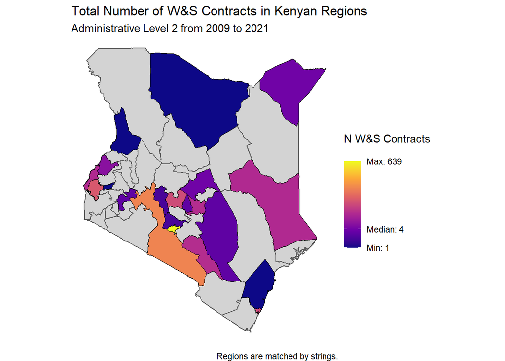

```r
#Top 5 Settlements by Contract Number (10 threshold)
settlements <- df %>%
  filter(water_cpv==1 | water_buyername==1 | water_tendertitle==1|water_biddername==1) %>%
  group_by(buyer_city) %>%
  summarise(n_water_contracts=n()) %>%
  filter(n_water_contracts>=10) %>%
  arrange(desc(n_water_contracts)) %>%
  head(5)

df_water <- df %>%
  filter(buyer_city%in%settlements$buyer_city) %>%
  filter(water_cpv==1 | water_buyername==1 | water_tendertitle==1 | water_biddername==1)
```

| tender_year | buyer_city | N |
| --- | --- | --- |
| 2018 | Mombasa | 20 |
| 2019 | Mombasa | 5 |
| 2021 | Mombasa | 1 |
| 2012 | Nairobi | 2 |
| 2014 | Nairobi | 1 |
| 2015 | Nairobi | 3 |
| 2016 | Nairobi | 16 |
| 2017 | Nairobi | 25 |
| 2018 | Nairobi | 303 |
| 2019 | Nairobi | 193 |
| 2020 | Nairobi | 46 |
| 2021 | Nairobi | 50 |
| 2019 | Nakuru | 89 |
| 2017 | Nyeri | 1 |
| 2018 | Nyeri | 16 |
| 2020 | Nyeri | 10 |
| 2018 | Siaya | 12 |
| 2019 | Siaya | 24 |

# Contract-Level Integrity Scores

The average integrity score for all contracts is 70.3 whereas for water-related contracts is 71.86.

| Integrity Indicator | All contracts | Water Contracts |
| --- | --- | --- |
| Decision Period | 44.25 | 53.28 |
| CfT Publication | 99.94 | 100 |
| Advertisement Period | 82.57 | 74.72 |
| Procedure Type | 92.96 | 95.1 |
| Single Bidding | 30.15 | 35.5 |

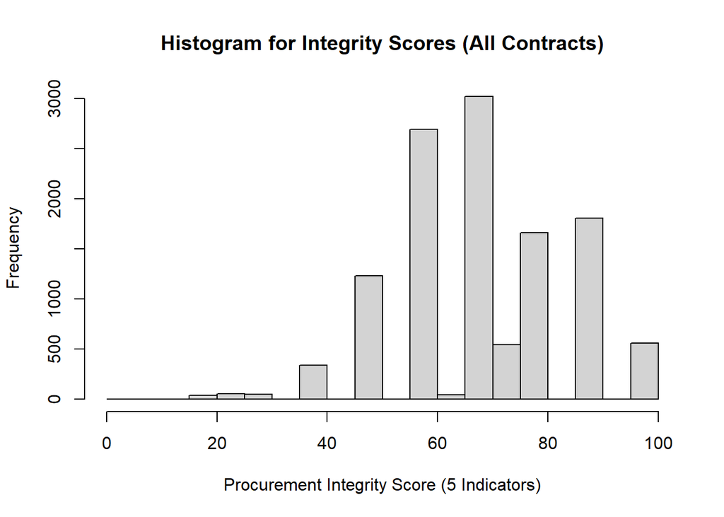

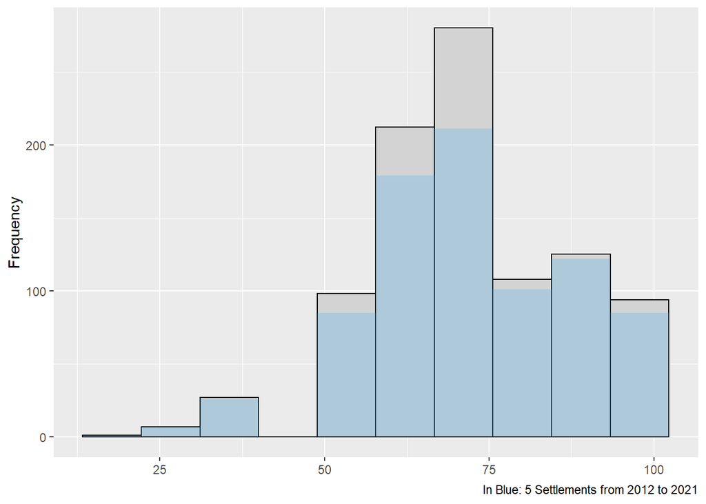

Full Procurement Data

| settlement_name | year | count_total | count_inv | count_op | count_int | count_pipe | avg_int_all | avg_int_inv | avg_int_op | avg_int_inter | avg_int_pipe | contract_value_total | contract_value_inv | contract_value_op | contract_value_int | contract_value_pipe |
| --- | --- | --- | --- | --- | --- | --- | --- | --- | --- | --- | --- | --- | --- | --- | --- | --- |
| Mombasa | 2018 | 20 | 10 | 3 | 2 | 1 | 67.00 | 65.50 | 66.67 | 70.00 | 60.00 | 90994050 | 79423323 | 2914101 | 16407187 | 3475650 |
| Mombasa | 2019 | 5 | 3 | 1 | NA | 1 | 68.00 | 70.00 | 60.00 | NA | 60.00 | 7766548 | 7406548 | 130000 | NA | 638000 |
| Mombasa | 2021 | 1 | 1 | NA | NA | NA | 60.00 | 60.00 | NA | NA | NA | 9650440 | 9650440 | NA | NA | NA |
| Nairobi | 2012 | 2 | 2 | NA | NA | 1 | 50.00 | 50.00 | NA | NA | 60.00 | 186444800 | 186444800 | NA | NA | 138789800 |
| Nairobi | 2014 | 1 | 1 | NA | NA | NA | 30.00 | 30.00 | NA | NA | NA | 233703000 | 233703000 | NA | NA | NA |
| Nairobi | 2015 | 3 | 2 | 1 | NA | NA | 73.33 | 80.00 | 60.00 | NA | NA | 13994105570 | 13984934486 | 9171084 | NA | NA |
| Nairobi | 2016 | 16 | 15 | 1 | 3 | 5 | 68.75 | 72.00 | 20.00 | 90.00 | 86.00 | 7555421871 | 7554952831 | 469040 | 425100219 | 6198344114 |
| Nairobi | 2017 | 25 | 17 | 5 | 3 | NA | 66.20 | 66.18 | 66.00 | 73.33 | NA | 3053727631 | 747458445 | 16266291 | 154513176 | NA |
| Nairobi | 2018 | 303 | 129 | 106 | 19 | 5 | 71.34 | 69.63 | 67.59 | 63.42 | 75.00 | 14443250196 | 12498724106 | 494072921 | 1319798444 | 4073244 |
| Nairobi | 2019 | 193 | 68 | 79 | 17 | 4 | 66.85 | 68.01 | 65.03 | 63.53 | 75.00 | 2557753539 | 1449299085 | 776920917 | 109263543 | 252801098 |
| Nairobi | 2020 | 46 | 34 | 11 | 1 | NA | 62.61 | 59.71 | 73.64 | 40.00 | NA | 3362792000 | 3289216613 | 73575387 | 195000 | NA |
| Nairobi | 2021 | 50 | 44 | 3 | 3 | 1 | 74.20 | 76.59 | 63.33 | 66.67 | 40.00 | 4417008239 | 4350539408 | 55540146 | 3956638959 | 0 |
| Nakuru | 2019 | 89 | 89 | NA | NA | NA | 97.75 | 97.75 | NA | NA | NA | 7773656575 | 7773656575 | NA | NA | NA |
| Nyeri | 2017 | 1 | 1 | NA | NA | NA | 50.00 | 50.00 | NA | NA | NA | 58271400 | 58271400 | NA | NA | NA |
| Nyeri | 2018 | 16 | 15 | 1 | NA | 5 | 61.25 | 60.67 | 70.00 | NA | 70.00 | 5833030687 | 5821167981 | 11862706 | NA | 22252576 |
| Nyeri | 2020 | 10 | 10 | NA | NA | 10 | 70.00 | 70.00 | NA | NA | 70.00 | 32948938 | 32948938 | NA | NA | 32948938 |
| Siaya | 2018 | 12 | 11 | 1 | NA | 1 | 62.92 | 63.18 | 60.00 | NA | 70.00 | 37730236 | 36855236 | 875000 | NA | 787485 |
| Siaya | 2019 | 24 | 23 | NA | NA | 9 | 65.42 | 65.65 | NA | NA | 68.33 | 86884333 | 85683833 | NA | NA | 69900670 |

# Pipeline Integrity Regression Calculations

[figure not shown]

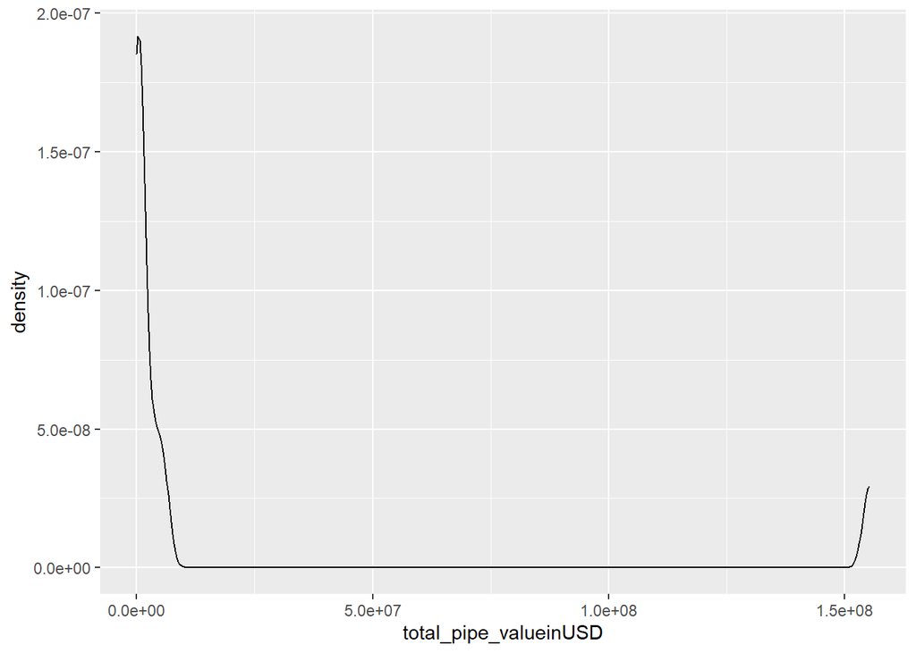

```
##    count_pipe
##  Min.   : 1.000
##  1st Qu.: 1.000
##  Median : 4.000
##  Mean   : 3.909
##  3rd Qu.: 5.000
##  Max.   :10.000
##  NA's   :7
```

```
##  total_pipe_valueinUSD total_pipe_valueinUSD ltotal_pipe_valueinUSD
##  Min.   :    14507     Min.   :    14507     Min.   : 9.582
##  1st Qu.:    85199     1st Qu.:    85199     1st Qu.:11.350
##  Median :   621274     Median :   621274     Median :13.327
##  Mean   : 16778426     Mean   : 16778426     Mean   :13.270
##  3rd Qu.:  3266934     3rd Qu.:  3266934     3rd Qu.:14.938
##  Max.   :155167520     Max.   :155167520     Max.   :18.860
##  NA's   :8             NA's   :8             NA's   :8
##  pipelength
##  Mode:logical
##  NA's:18
##
##
##
##
##
```

```
##  total_pipe_valueinUSD total_pipe_valueinUSD pipelength     pipelength
##  Min.   :    14507     Min.   :    14507     Mode:logical   Mode:logical
##  1st Qu.:    85199     1st Qu.:    85199     NA's:18        NA's:18
##  Median :   621274     Median :   621274
##  Mean   : 16778426     Mean   : 16778426
##  3rd Qu.:  3266934     3rd Qu.:  3266934
##  Max.   :155167520     Max.   :155167520
##  NA's   :8             NA's   :8
```

# Indicator Weights

Indicator weights are calculated from the Pilot Version of the Water Integrity Risk Index (WIRI) available at the [GTI Website](http://www.govtransparency.eu/water-and-sanitation-sector-integrity-risk-index/).

|  | Missing Rate | WIRI Weight |
| --- | --- | --- |
| avg_cri_inv_int_100 | 0.90 | 0.35 |
| pipe_int | 0.34 | 0.13 |
| avg_cri_op_int_100 | 0.89 | 0.35 |
| avg_cri_inter_int_100 | 0.40 | 0.15 |
| cui_survey_int | 0.04 | 0.02 |

# Cross-Sectional WIRI

| settlement_name | WIRI | wiri_inv | wiri_ops | wiri_cui |
| --- | --- | --- | --- | --- |
| Mombasa | 65.36 | 65.17 | 63.33 | 70.00 |
| Nairobi | 56.98 | 63.57 | 59.37 | 33.48 |
| Nyeri | 53.32 | 60.22 | 70.00 | 0.00 |
| Siaya | 51.89 | 64.42 | 60.00 | 0.00 |

```r
#Mean
sapply(WIRI[,c("WIRI","wiri_inv","wiri_ops","wiri_cui")], mean, na.rm=T)
```

```
##     WIRI wiri_inv wiri_ops wiri_cui
## 56.88769 63.34369 63.17604 25.86926
```

```r
#Median
sapply(WIRI[,c("WIRI","wiri_inv","wiri_ops","wiri_cui")], median, na.rm=T)
```

```
##     WIRI wiri_inv wiri_ops wiri_cui
## 55.14978 63.99293 61.66667 16.73852
```

# Time Series WIRI

| settlement_name | year | WIRI_ts | wiri_inv_ts | wiri_ops_ts | wiri_cui_ts |
| --- | --- | --- | --- | --- | --- |
| Mombasa | 2018 | 66.67 | 65.50 | 66.67 | 70.00 |
| Mombasa | 2019 | 54.59 | 70.00 | 60.00 | 0.00 |
| Nairobi | 2015 | 59.43 | 80.00 | 60.00 | 0.00 |
| Nairobi | 2016 | 49.50 | 72.00 | 20.00 | 45.47 |
| Nairobi | 2017 | 67.34 | 66.18 | 66.00 | 73.33 |
| Nairobi | 2018 | 67.87 | 69.63 | 67.59 | 63.42 |
| Nairobi | 2019 | 60.85 | 68.01 | 65.03 | 32.09 |
| Nairobi | 2020 | 61.15 | 59.71 | 73.64 | 40.00 |
| Nairobi | 2021 | 70.32 | 76.59 | 63.33 | 66.67 |
| Nyeri | 2018 | 53.53 | 60.67 | 70.00 | 0.00 |
| Siaya | 2018 | 51.30 | 63.18 | 60.00 | 0.00 |

# WIRI Visualizations

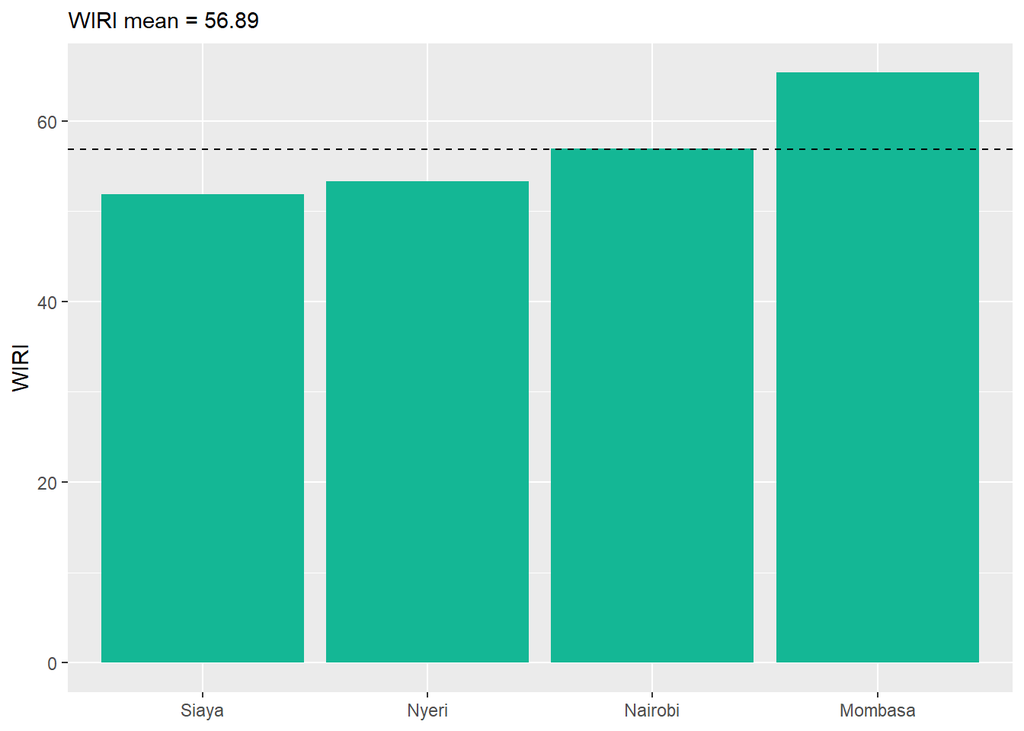

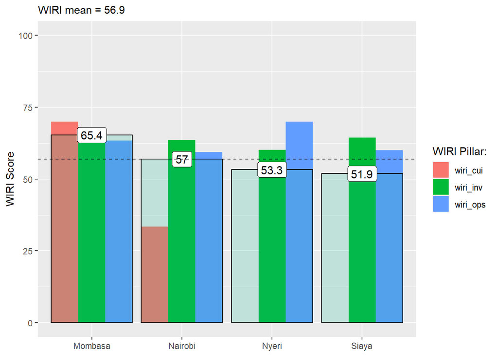

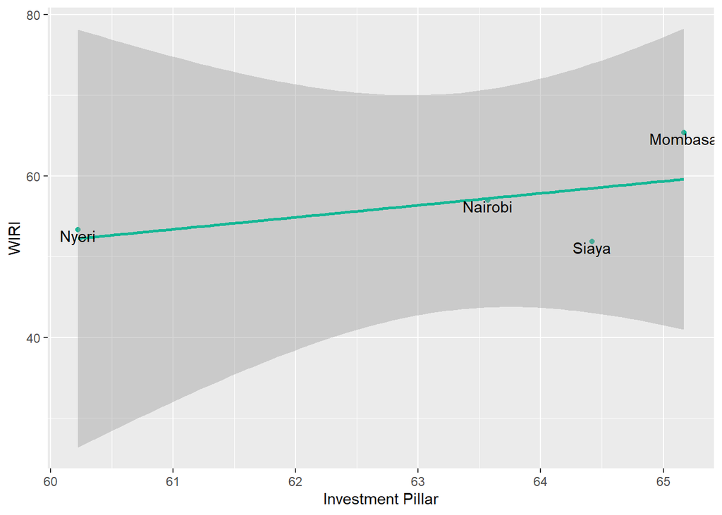

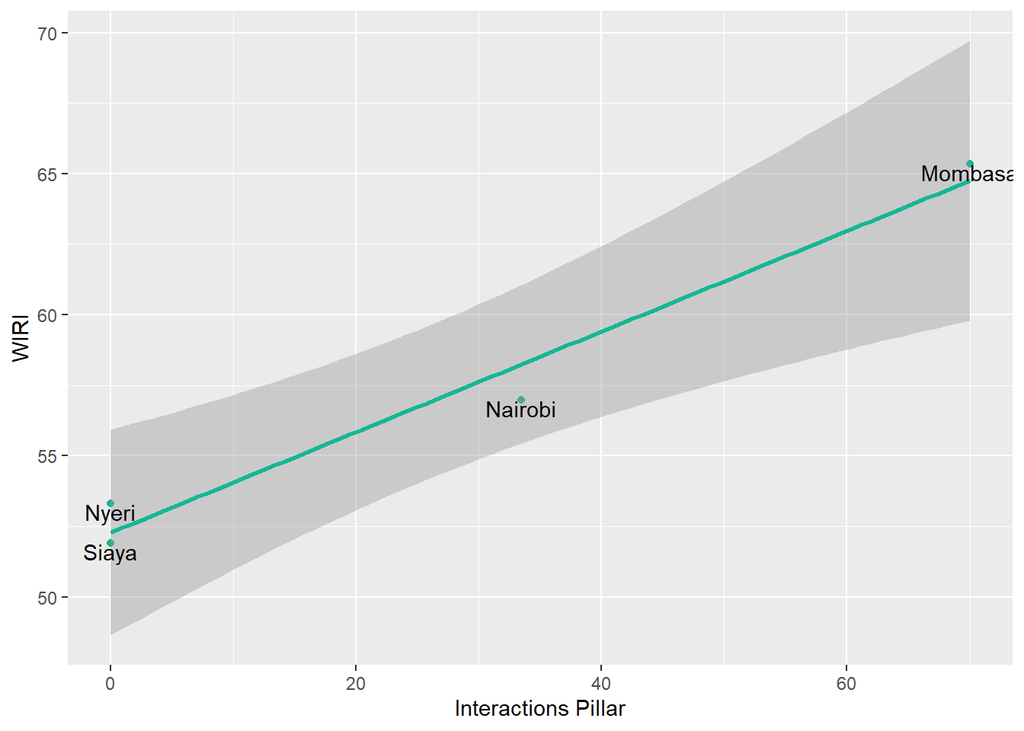

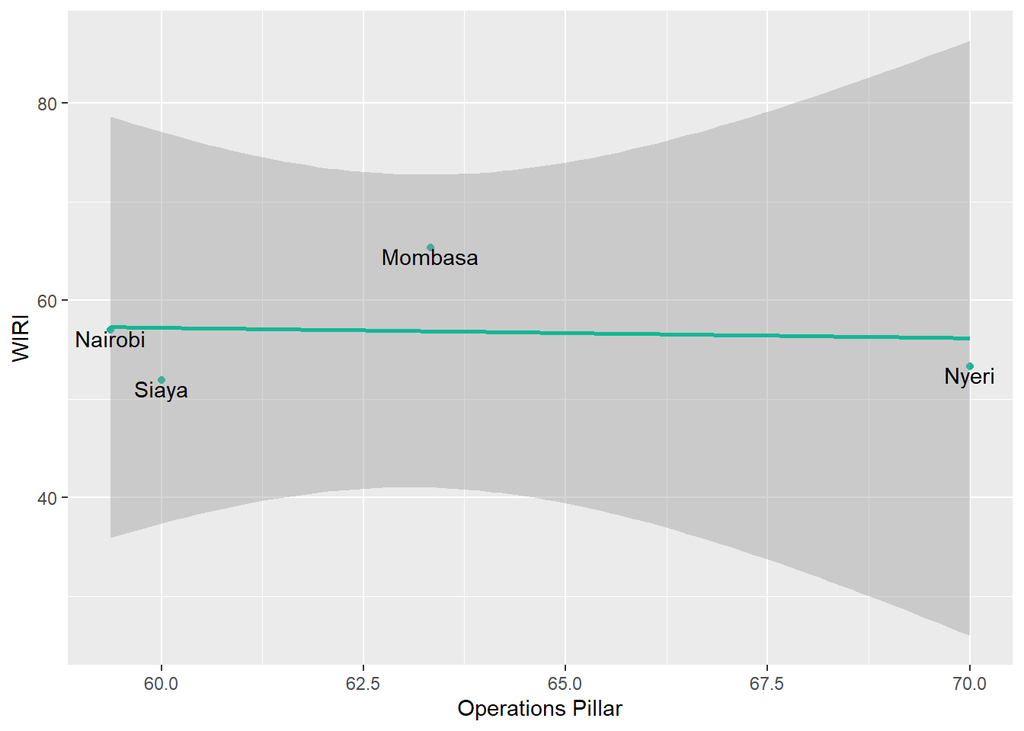

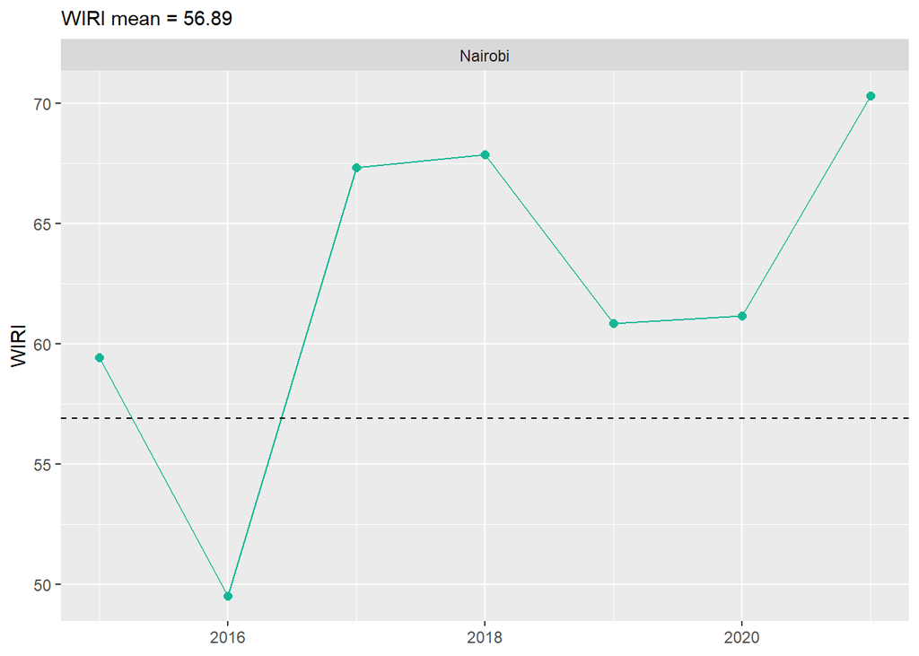

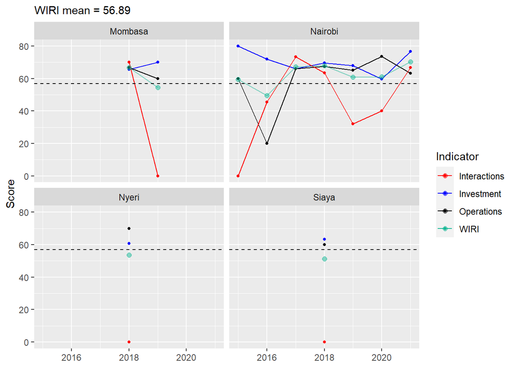